# - TP n°4 : Arbres de classification -

*Thomas Koch*

```python
############################################################################
#                Import part
############################################################################
import numpy as np
import matplotlib.pyplot as plt
from matplotlib.colors import ListedColormap
from math import fmod
import seaborn as sns
```

```python
############################################################################
#                Data Generation
############################################################################


def rand_gauss(n=100, mu=[1, 1], sigma=[0.1, 0.1]):
    """ Sample n points from a Gaussian variable with center mu,
    and std deviation sigma
    """
    d = len(mu)
    res = np.random.randn(n, d)
    return np.array(res * sigma + mu)


def rand_bi_gauss(n1=100, n2=100, mu1=[1, 1], mu2=[-1, -1], sigma1=[0.1, 0.1],
                  sigma2=[0.1, 0.1]):
    """ Sample n1 and n2 points from two Gaussian variables centered in mu1,
    mu2, with std deviation sigma1, sigma2
    """
    ex1 = rand_gauss(n1, mu1, sigma1)
    ex2 = rand_gauss(n2, mu2, sigma2)
    res = np.vstack([np.hstack([ex1, 1. * np.ones((n1, 1))]),
                     np.hstack([ex2, 2. * np.ones((n2, 1))])])
    ind = np.arange(res.shape[0])
    np.random.shuffle(ind)
    return np.array(res[ind, :])


def rand_tri_gauss(n1=100, n2=100, n3=100, mu1=[1, 1],
                   mu2=[-1, -1], mu3=[1, -1], sigma1=[0.1, 0.1],
                   sigma2=[0.1, 0.1], sigma3=[0.1, 0.1]):
    """ Sample n1, n2 and n3 points from three Gaussian variables centered in mu1,
    mu2 and mu3 with std deviation sigma1, sigma2 and sigma3
    """
    ex1 = rand_gauss(n1, mu1, sigma1)
    ex2 = rand_gauss(n2, mu2, sigma2)
    ex3 = rand_gauss(n3, mu3, sigma3)
    res = np.vstack([np.hstack([ex1, 1. * np.ones((n1, 1))]),
                     np.hstack([ex2, 2. * np.ones((n2, 1))]),
                     np.hstack([ex3, 3. * np.ones((n3, 1))])])
    ind = np.arange(res.shape[0])
    np.random.shuffle(ind)
    return np.array(res[ind, :])


def rand_clown(n1=100, n2=100, sigma1=1, sigma2=2):
    """ Sample a dataset clown  with
    n1 points and noise std deviation sigma1 for the first class, and
    n2 points and noise std deviation sigma2 for the second one
    """
    x0 = np.random.randn(n1)
    x1 = x0 * x0 + sigma1 * np.random.randn(n1)
    x2 = np.vstack([sigma2 * np.random.randn(n2),
                    sigma2 * np.random.randn(n2) + 2.])
    res = np.hstack([np.vstack([[x0, x1], 1. * np.ones([1, n1])]),
                     np.vstack([x2, 2. * np.ones([1, n2])])]).T
    ind = np.arange(res.shape[0])
    np.random.shuffle(ind)
    return np.array(res[ind, :])


def rand_checkers(n1=100, n2=100, n3=100, n4=100, sigma=0.1):
    """ Sample n1 and n2 points from a noisy checker"""
    nb1 = n1 // 8
    nb2 = n2 // 8
    nb3 = n3 // 8
    nb4 = n4 // 8

    xapp = np.reshape(np.zeros((nb1 + nb2 + nb3 + nb4) * 16),
                      [(nb1 + nb2 + nb3 + nb4) * 8, 2])
    yapp = np.ones((nb1 + nb2 + nb3 + nb4) * 8)
    idx = 0
    nb = 2 * nb1
    for i in range(-2, 2):
        for j in range(-2, 2):
            yapp[idx:(idx + nb)] = [fmod(i - j + 100, 4)] * nb
            xapp[idx:(idx + nb), 0] = np.random.rand(nb)
            xapp[idx:(idx + nb), 0] += i + sigma * np.random.randn(nb)
            xapp[idx:(idx + nb), 1] = np.random.rand(nb)
            xapp[idx:(idx + nb), 1] += j + sigma * np.random.randn(nb)
            idx += nb

    ind = np.arange((nb1 + nb2 + nb3 + nb4) * 8)
    np.random.shuffle(ind)
    res = np.hstack([xapp, yapp[:, np.newaxis]])
    return np.array(res[ind, :])
```

```python
############################################################################
#            Displaying labeled data
############################################################################
symlist = ['o', 's', 'D', 'x', '+', '*', 'p', 'v', '-', '^']


def plot_2d(data, y=None, w=None, alpha_choice=1):
    """ Plot in 2D the dataset data, colors and symbols according to the
    class given by the vector y (if given); the separating hyperplan w can
    also be displayed if asked"""

    k = np.unique(y).shape[0]
    color_blind_list = sns.color_palette("colorblind", k)
    sns.set_palette(color_blind_list)
    if y is None:
        labs = [""]
        idxbyclass = [range(data.shape[0])]
    else:
        labs = np.unique(y)
        idxbyclass = [np.where(y == labs[i])[0] for i in range(len(labs))]

    for i in range(len(labs)):
        plt.scatter(data[idxbyclass[i], 0], data[idxbyclass[i], 1],
                    c=np.reshape(color_blind_list[i], (1, -1)), s=80,
                    marker=symlist[i])
    plt.ylim([np.min(data[:, 1]), np.max(data[:, 1])])
    plt.xlim([np.min(data[:, 0]), np.max(data[:, 0])])
    mx = np.min(data[:, 0])
    maxx = np.max(data[:, 0])
    if w is not None:
        plt.plot([mx, maxx], [mx * -w[1] / w[2] - w[0] / w[2],
                              maxx * -w[1] / w[2] - w[0] / w[2]],
                 "g", alpha=alpha_choice)


def plot_2d_simple(data, y=None):
    if y is None:
        plt.scatter(data[:, 0], data[:, 1], s=50)
    else:
        nY = len(y)
        y = y.astype(int)
        Ycol = [collist[y[i] - 1 % len(collist)] for i in range(nY)]
        plt.scatter(data[:, 0], data[:, 1], c=Ycol, s=40)
```

```python
############################################################################
#            Displaying tools for the Frontiere
############################################################################


def frontiere_new(f, X, y, w=None, step=50, alpha_choice=1, colorbar=True,
                  samples=True):
    """ trace la frontiere pour la fonction de decision f"""
    # construct cmap

    min_tot0 = np.min(X[:, 0])
    min_tot1 = np.min(X[:, 1])

    max_tot0 = np.max(X[:, 0])
    max_tot1 = np.max(X[:, 1])
    delta0 = (max_tot0 - min_tot0)
    delta1 = (max_tot1 - min_tot1)
    xx, yy = np.meshgrid(np.arange(min_tot0, max_tot0, delta0 / step),
                         np.arange(min_tot1, max_tot1, delta1 / step))
    z = np.array([f(vec) for vec in np.c_[xx.ravel(), yy.ravel()]])
    z = z.reshape(xx.shape)
    labels = np.unique(z)
    color_blind_list = sns.color_palette("colorblind", labels.shape[0])
    sns.set_palette(color_blind_list)
    my_cmap = ListedColormap(color_blind_list)
    plt.imshow(z, origin='lower', interpolation="mitchell", alpha=0.80,
               cmap=my_cmap, extent=[min_tot0, max_tot0, min_tot1, max_tot1])
    if colorbar is True:
        ax = plt.gca()
        cbar = plt.colorbar(ticks=labels)
        cbar.ax.set_yticklabels(labels)

    labels = np.unique(y)
    k = np.unique(y).shape[0]
    color_blind_list = sns.color_palette("colorblind", k)
    sns.set_palette(color_blind_list)
    ax = plt.gca()
    if samples is True:
        for i, label in enumerate(y):
            label_num = np.where(labels == label)[0][0]
            plt.scatter(X[i, 0], X[i, 1],
                        c=np.reshape(color_blind_list[label_num], (1, -1)),
                        s=80, marker=symlist[label_num])
    plt.xlim([min_tot0, max_tot0])
    plt.ylim([min_tot1, max_tot1])
    ax.get_yaxis().set_ticks([])
    ax.get_xaxis().set_ticks([])
    if w is not None:
        plt.plot([min_tot0, max_tot0],
                 [min_tot0 * -w[1] / w[2] - w[0] / w[2],
                  max_tot0 * -w[1] / w[2] - w[0] / w[2]],
                 "k", alpha=alpha_choice)
```

### Question 1 : Cadre de la régression

Dans le cadre de la régression (*i.e.*, quand on cherche à prédire une valeur numérique pour $Y$ et non une classe), proposez une autre mesure d’homogénéité. Justifier votre choix.

> Dans le cadre de la régression, une mesure d'homogénéité correspond à la **variance**.

Avec `scikit-learn` on peut construire des arbres de décision grâce au package `tree`. On obtient un classifieur avec `tree.DecisionTreeClassifier`.

```python
from sklearn import tree
```

### Question 2 : Pourcentage d'erreurs en fonction de la profondeur de l'arbre

Simulez avec `rand_checkers` des échantillons de taille n = 456 (attention à bien équilibrer les classes). Créez deux courbes qui donnent le pourcentage d’erreurs commises en fonction de la profondeur maximale de l’arbre (une courbe pour Gini, une courbe pour l’entropie). On laissera les autres paramètres à leur valeurs par défaut.

```python
# Génération des données
n1 = 114
n2 = 114
n3 = 114
n4 = 114
sigma = 0.1
data4 = rand_checkers(n1, n2, n3, n4, sigma)

data4.shape
```

```
(448, 3)
```

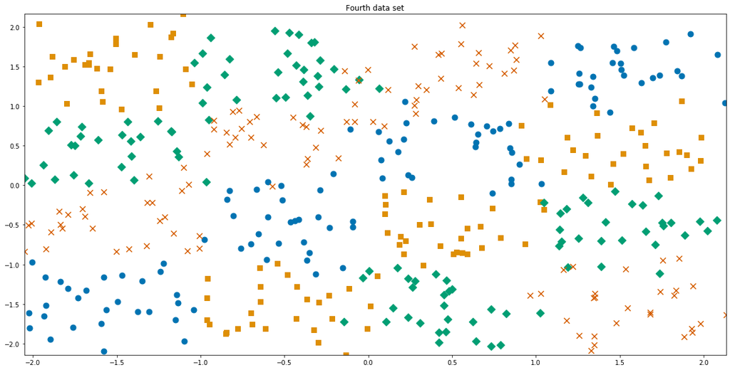

```python
# Displaying labeled data
plt.close("all")

plt.figure(1, figsize=(20, 10))
plt.subplot()
plt.title('Fourth data set')
plot_2d(data4[:, :2], data4[:, 2], w=None)
```

> On entraîne notre modèle sur toutes les données

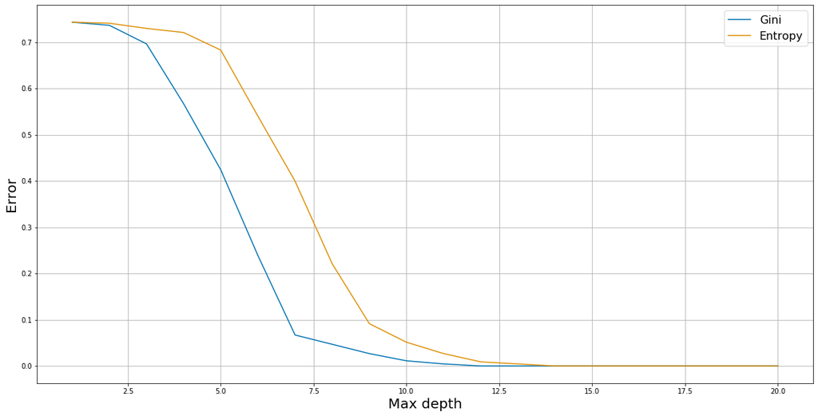

```python
X = data4[:, :-1]
Y = data4[:, -1]

# Afficher les scores en fonction du paramètre max_depth

dmax = 20
scores = np.zeros((2,dmax))
trees = {}


for j, crit in enumerate(['gini', 'entropy'], 0):
    for depth in range(1,dmax+1):
        #print(crit,j)
        dt = tree.DecisionTreeClassifier(criterion=crit, max_depth=depth)
        dt.fit(X, Y)
        trees[(j, depth)] = dt
        # error = 1 - dt.score(X, Y)
        scores[j, depth-1] = dt.score(X, Y)  # Accuracy score

#print(scores)

plt.close(2)
plt.figure(2, figsize=(20, 10))
plt.plot(np.arange(1, dmax + 1), 1-scores[0,], label="Gini")
plt.plot(np.arange(1, dmax + 1), 1-scores[1,], label="Entropy")
plt.xlabel('Max depth', size=20)
plt.ylabel('Error', size=20)
plt.legend(fontsize=16)
plt.grid(True)
plt.show()
```

> Les résultats sont donc meilleurs avec le critère de Gini puisque le taux d'erreur est le plus faible même quand on fait varier la profondeur de l'arbre.

> Voyons ce que nous obtenons en entraînant sur un échantillon d'entraînement et testant sur un échantillon de test.

```python
from sklearn.model_selection import train_test_split

# Split data into train set and test set
X_train, X_test, Y_train, Y_test = train_test_split(X, Y, test_size=0.3)
```

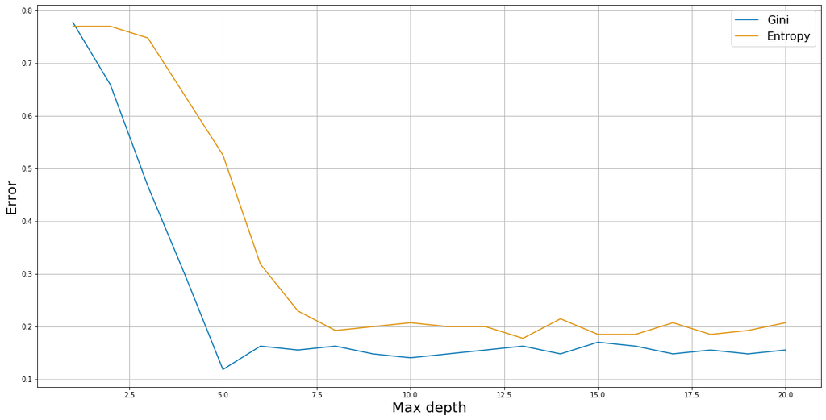

```python
# Afficher les scores en fonction du paramètre max_depth

dmax = 20
scores_test = np.zeros((2,dmax))
trees = {}


for j, crit in enumerate(['gini', 'entropy'], 0):
    for depth in range(1,dmax+1):
        #print(crit,j)
        dt = tree.DecisionTreeClassifier(criterion=crit, max_depth=depth)
        dt.fit(X_train, Y_train)
        trees[(j, depth)] = dt
        # error = 1 - dt.score(X, Y)
        scores[j, depth-1] = dt.score(X_test, Y_test)  # Accuracy score


plt.figure(3, figsize=(20, 10))
plt.plot(np.arange(1, dmax + 1), 1-scores[0,], label="Gini")
plt.plot(np.arange(1, dmax + 1), 1-scores[1,], label="Entropy")
plt.xlabel('Max depth', size=20)
plt.ylabel('Error', size=20)
plt.legend(fontsize=16)
plt.grid(True)
plt.show()
```

### Question 3 : Règle de classification obtenue

Afficher la règle de classification obtenues en utilisant la profondeur qui minimise le pourcentage d’erreurs obtenues avec l’entropie et avec l’indice de Gini (utiliser si besoin les fonctions `plot_2d` et `frontiere_new` du fichier source).

> On restera sur le jeu complet pour faciliter l'analyse

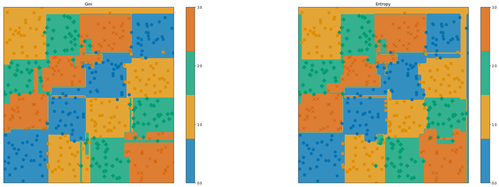

```python
plt.figure(figsize=(30,10))

plt.subplot(121)
dt1 = tree.DecisionTreeClassifier(criterion='gini', max_depth = 16)
dt1.fit(X,Y)
plt.title("Gini")
frontiere_new(lambda x : dt1.predict(x.reshape((1, -1))), X, Y, step=100)


plt.subplot(122)
dt2 = tree.DecisionTreeClassifier(criterion='entropy', max_depth = 16)
dt2.fit(X,Y)
plt.title("Entropy")
frontiere_new(lambda x : dt2.predict(x.reshape((1, -1))), X, Y, step=100)

plt.show()
```

### Question 4 : Export des graphiques

Exporter des graphiques des arbres obtenu à la question précédente en format pdf. On pourra par exemple utiliser la fonction `export_graphviz` du module `tree`.

```python
tree.export_graphviz(dt1, out_file="myTestTree.dot", filled=True)

import os
os.system("dot -Tpdf myTestTree.dot -o myTestTree.pdf")
#!open myTestTree.pdf
os.system("evince myTestTree.pdf")
```

```
32512
```

### Question 5 : Validation des modèles de la question 2 avec d'autres observations

Créez $n = 160 = 40 + 40 + 40 + 40$ nouvelles données avec `rand_checkers`. Pour les arbres de décision entraînés précédemment (dans partie (2)), calculer la proportion d’erreurs faites sur cet échantillon de test. Commenter.

```python
# Génération des données
n1 = 40
n2 = 40
n3 = 40
n4 = 40
sigma = 0.1
data4_test = rand_checkers(n1, n2, n3, n4, sigma)

data4_test.shape
```

```
(160, 3)
```

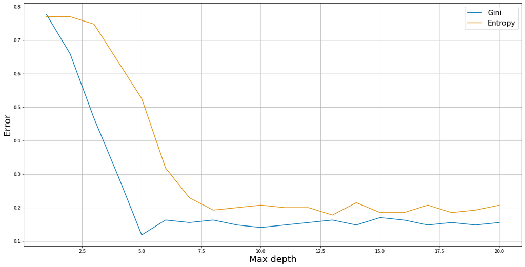

```python
X_test_q5 = data4[:, :-1]
Y_test_q5 = data4[:, -1]

# Afficher les scores en fonction du paramètre max_depth

dmax = 20
scores_test_q5 = np.zeros((2,dmax))


for j, crit in enumerate(['gini', 'entropy'], 0):
    for depth in range(1,dmax+1):
        dt = trees[(j, depth)]
        scores_test_q5[j, depth-1] = dt.score(X_test_q5, Y_test_q5)
        # error = 1 - dt.score(X, Y)


plt.figure(5, figsize=(20, 10))
plt.plot(np.arange(1, dmax + 1), 1-scores[0,], label="Gini")
plt.plot(np.arange(1, dmax + 1), 1-scores[1,], label="Entropy")
plt.xlabel('Max depth', size=20)
plt.ylabel('Error', size=20)
plt.legend(fontsize=16)
plt.grid(True)
plt.show()
```

> Le taux d'erreur se stabilise à une valeur faible aux alentours d'une profondeur d'arbre de 7.

### Question 6 : Application à la base de données digit

Reprendre les questions précédentes pour le dataset zipcode. Ce jeu de données est disponible dans le module `sklearn.datasets`. On peut l’importer avec la fonction `load_digits` du dit module (ou voir pour plus de détails http://scikit-learn.org/stable/auto_examples/classification/plot_digits_classification.html) :

```
digits = datasets.load_digits()
```

```python
from sklearn.datasets import load_digits
# Import the digits dataset
digits = load_digits()

n_samples = len(digits.data)
data = digits.images.reshape((n_samples, -1))
label = digits.target

X_dig = digits.data[:n_samples // 2]
Y_dig = digits.target[:n_samples // 2]
X_test_dig = digits.data[n_samples // 2:]
Y_test_dig = digits.target[n_samples // 2:]
```

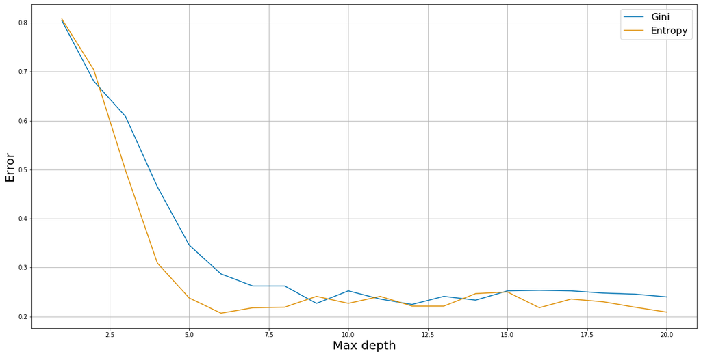

```python
dmax = 20
scores_test_q6 = np.zeros((2,dmax))

for j, crit in enumerate(['gini', 'entropy'], 0):
    for depth in range(1,dmax+1):
        dt = tree.DecisionTreeClassifier(criterion=crit, max_depth=depth)
        dt.fit(X_dig, Y_dig)
        scores_test_q6[j, depth-1] = dt.score(X_test_dig, Y_test_dig)
        # error = 1 - dt.score(X, Y)


plt.figure(6, figsize=(20, 10))
plt.plot(np.arange(1, dmax + 1), 1-scores_test_q6[0,], label="Gini")
plt.plot(np.arange(1, dmax + 1), 1-scores_test_q6[1,], label="Entropy")
plt.xlabel('Max depth', size=20)
plt.ylabel('Error', size=20)
plt.legend(fontsize=16)
plt.grid(True)
plt.show()
```

## Méthodes de choix de paramètres - Sélection de modèle

Il est rare de disposer en pratique d’un ensemble de test (on préfère inclure le plus grand nombre de données dans l’ensemble d’apprentissage), c’est au praticien de garder une partie de ces données à cet effet. Pour sélectionner un modèle ou un paramètre tout en considérant le plus grand nombre d’exemples possibles pour l’apprentissage, on utilise généralement une sélection par validation croisée. Pour chaque paramètre utilisé, une estimation de l’erreur empirique du classifieur est obtenue selon la procédure suivante. On fixe d’abord un entier $N$, souvent $N = 5$ ou $N = 10$, qui représente le nombre de blocs (en anglais : fold) et un jeu de paramètre du modèle :

- l’ensemble d’apprentissage est partitionné en $N$ blocs de taille $n/N$
- pour chaque sous-ensemble possible, on mesure l’erreur obtenue par le classifieur (pour un jeu de paramètres fixé) appris sur les $N − 1$ blocs restants.
- l’erreur estimée est la moyenne de l’erreur des classifieurs appris. On peut répéter cette procédure sur toute la grille des paramètres. Cela permet d’obtenir une mesure d’erreur pour chaque paramètre, et finalement on choisit le paramètre minimisant cette quantité. Pour plus de détails sur les variantes de ce principe implémentées dans `scikit-learn`, consultez la page http://scikit-learn.org/stable/modules/cross_validation.html.

### Question 7 : `cross_val_score`

Utiliser la fonction `sklearn.model_selection.cross_val_score` et tester la sur le jeu de données digits en faisant varier la profondeur de l’arbre de décision. On pourra se servir de cette fonction pour choisir la profondeur de l’arbre.

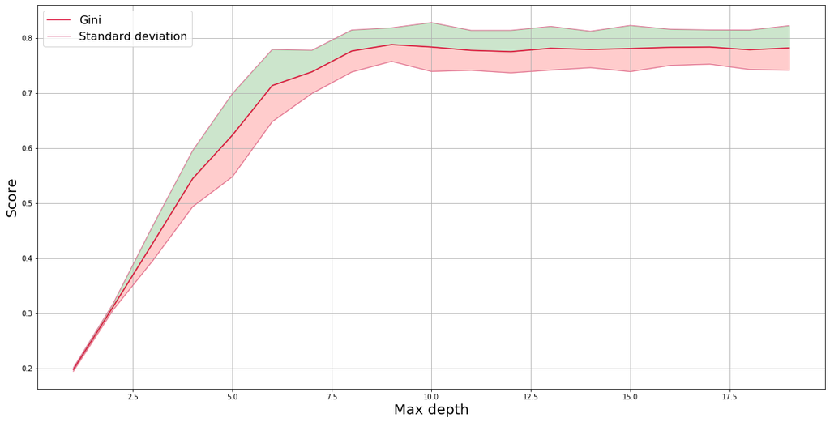

```python
from sklearn.model_selection import cross_val_score

X = data
Y = label
t = tree.DecisionTreeClassifier()
scores = cross_val_score(t, X, Y, cv=5)

depths = np.arange(1, 20)

scores = list()
scores_std = list()

for depth in depths:
    t.max_depth = depth
    this_scores = cross_val_score(t, X, Y, cv=5)
    scores.append(np.mean(this_scores))
    scores_std.append(np.std(this_scores))

plt.figure(figsize=(20,10))
plt.plot(depths, scores, color="crimson", label="Gini")
plt.plot(depths, np.array(scores) + np.array(scores_std), color="palevioletred", linewidth=1, label='Standard deviation')
plt.plot(depths, np.array(scores) - np.array(scores_std), color="palevioletred", linewidth=1)
plt.fill_between(depths, scores, np.array(scores) + np.array(scores_std), color="green", alpha=0.2)
plt.fill_between(depths, scores, np.array(scores) - np.array(scores_std), color="red", alpha=0.2)
plt.xlabel('Max depth', size = 20)
plt.ylabel('Score', size = 20)
plt.legend(fontsize=16)
plt.grid(True)
plt.show()
```

### Question 8 : `learning_curve`

En s’inspirant de http://scikit-learn.org/stable/auto_examples/model_selection/plot_learning_curve.html afficher la courbe d’apprentissage (en : learning curve) pour les arbres de décisions sur le même jeu de données.

```python
from sklearn.model_selection import learning_curve

def plot_learning_curve(estimator, title, X, y, ylim=None, cv=None,
                        n_jobs=1, train_sizes=np.linspace(.1, 1.0, 5)):
    """
    Generate a simple plot of the test and training learning curve.

    Parameters
    ----------
    estimator : object type that implements the "fit" and "predict" methods
        An object of that type which is cloned for each validation.

    title : string
        Title for the chart.

    X : array-like, shape (n_samples, n_features)
        Training vector, where n_samples is the number of samples and
        n_features is the number of features.

    y : array-like, shape (n_samples) or (n_samples, n_features), optional
        Target relative to X for classification or regression;
        None for unsupervised learning.

    ylim : tuple, shape (ymin, ymax), optional
        Defines minimum and maximum yvalues plotted.

    cv : int, cross-validation generator or an iterable, optional
        Determines the cross-validation splitting strategy.
        Possible inputs for cv are:
          - None, to use the default 3-fold cross-validation,
          - integer, to specify the number of folds.
          - An object to be used as a cross-validation generator.
          - An iterable yielding train/test splits.

        For integer/None inputs, if ``y`` is binary or multiclass,
        :class:`StratifiedKFold` used. If the estimator is not a classifier
        or if ``y`` is neither binary nor multiclass, :class:`KFold` is used.

        Refer :ref:`User Guide <cross_validation>` for the various
        cross-validators that can be used here.

    n_jobs : integer, optional
        Number of jobs to run in parallel (default 1).
    """
    plt.figure()
    plt.title(title)
    if ylim is not None:
        plt.ylim(*ylim)
    plt.xlabel("Training examples")
    plt.ylabel("Score")
    train_sizes, train_scores, test_scores = learning_curve(
        estimator, X, y, cv=cv, n_jobs=n_jobs, train_sizes=train_sizes)
    train_scores_mean = np.mean(train_scores, axis=1)
    train_scores_std = np.std(train_scores, axis=1)
    test_scores_mean = np.mean(test_scores, axis=1)
    test_scores_std = np.std(test_scores, axis=1)
    plt.grid()

    plt.fill_between(train_sizes, train_scores_mean - train_scores_std,
                     train_scores_mean + train_scores_std, alpha=0.1,
                     color="r")
    plt.fill_between(train_sizes, test_scores_mean - test_scores_std,
                     test_scores_mean + test_scores_std, alpha=0.1, color="g")
    plt.plot(train_sizes, train_scores_mean, 'o-', color="r",
             label="Training score")
    plt.plot(train_sizes, test_scores_mean, 'o-', color="g",
             label="Cross-validation score")

    plt.legend(loc="best")
    return plt
```

```
<module 'matplotlib.pyplot' from '/home/p5hngk/anaconda3/lib/python3.7/site-packages/matplotlib/pyplot.py'>
```

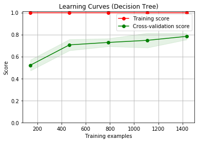

```python
title = "Learning Curves (Decision Tree)"

estimator_0 = tree.DecisionTreeClassifier()
plot_learning_curve(estimator_0, title, X, Y, ylim=(0, 1.01), cv=5)
```

```
<module 'matplotlib.pyplot' from '/home/p5hngk/anaconda3/lib/python3.7/site-packages/matplotlib/pyplot.py'>
```

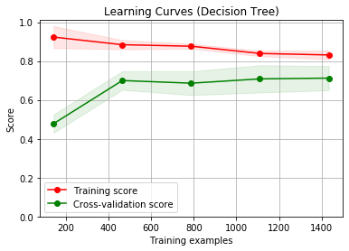

```python
title = "Learning Curves (Decision Tree)"

estimator = tree.DecisionTreeClassifier(max_depth = 6)
plot_learning_curve(estimator, title, X, Y, ylim=(0, 1.01), cv=5)
```

> If the training score is much greater than the validation score for the maximum number of training samples, adding more training samples will most likely increase generalization. In the above plot you can see that the DecisionTree could benefit from more training examples.